# Session3: Visualisation avec ggplot

Visseho Adjiwanou, PhD.

08 June 2021

## Plan

- Introduction
- Type de graphiques pour les distributions univariées et bivariées
- Présentation de ggplot de tidyverse
- Visualisation de distribution univariée
- Visualisation de distribution bivariée
- Remarques
- Ressources

# Introduction

## Introduction

- R dispose de plusieurs systèmes pour créer des graphiques, mais ggplot2 est l’un des plus élégants et des plus polyvalents.
- Avec ggplot2, vous pouvez faire plus rapidement en apprenant un système et en l’appliquant à de nombreux graphiques.
- Parce qu'il fait partie de `tidyverse`:
- Il sera chargé automatiquement une fois que vous chargez tidyverse;
- Il va fonctionner sur les bases de données ou les `tribbles`

## Introduction

```r
library(tidyverse)
```

## Introduction

- Les graphiques nous permettent de répondre à plusieurs types de questions :
- Quelle est la distribution d'une variable?
- Est-ce que les filles ont plus tendances à vivre dans un type particulier de structure familiale?
- Comment est-ce que la structure de la famille affecte la santé des enfants?
- Est-ce qu'il existe une association entre les attitudes envers la violence conjugale et le niveau de scolarisation (données dhs_ipv)
- Cette relation est-elle positive? négative? ou nulle?

# Type de graphiques pour les distributions univariées et bivariées

## Les types de graphiques

- Dépend en général du type de variable (qualitative ou quantitative) et du nombre de variable
- Graphiques pour representer une seule variable:

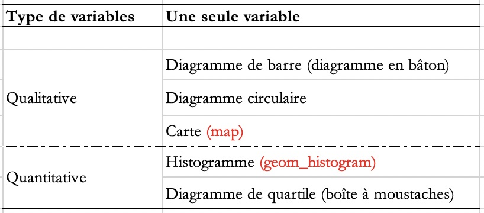

## Les types de graphiques

- Graphiques pour representer l'association entre deux variables

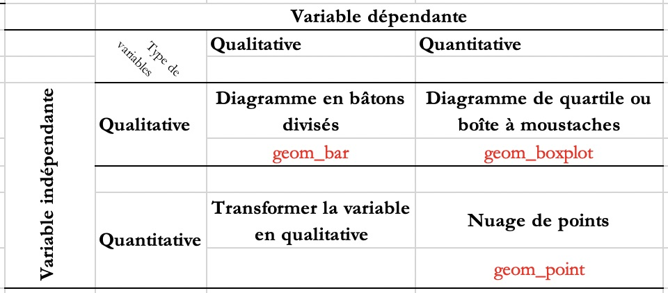

# ggplot

## Forme générale

- La forme générale d'un code de graphique est le suivant:
1. **ggplot** spécifie que vous utilisez la commande ggplot. C'est à ce niveau que vous spécifiez les données que vous voulez utiliser.
- Ce n'est pas toujours obligatoire si vous utilisez plus d'une base de données.

## Forme générale

- La forme générale d'un code de graphique est le suivant:
3. **aes** pour aestetics indique le nombre de paramètres à passer à la fonction **geom_function**. Il permet également de spécifier des informations sur le graphique.

# Exemples: Visualiser la distribution univariée

## Introduction

- Nous allons utiliser les données dhs_ipv

```r
library(tidyverse)

dhs_ipv <- read_csv("../données/dhs_ipv.csv")
dhs_ipv <-
  dhs_ipv %>%
  mutate(beat_burnfood_cat = factor(ntile(beat_burnfood, 4),
                                    labels = c('très faible', 'faible', 'élevé', 'très élevé')),
         beat_goesout_cat = factor(ntile(beat_goesout, 4),
                                   labels = c('très faible', 'faible', 'élevé', 'très élevé')),
         sec_school_cat = factor(ntile(sec_school, 3),
                                 labels = c('pauvre', 'moyen', 'riche')),
         no_media_cat = factor(ntile(no_media, 3),
                               labels = c('riche', 'moyen', 'pauvre')))
```

## Introduction

- et les données crsc_small, que vous connaissez bien.

```r
crsc96 <- read_csv("../données/cora-crsc1996-E-1996_F1.csv")
crsc96_small <-
  crsc96 %>%
  select(sexq, region, age, ageq, q1, q2, q3, q4, q44, q95) %>%
  mutate(sexe = factor(sexq, labels = c("Homme", "Femme")),
         q2_new = factor(q2,
                         labels = c("totally agree", "agree somewhat",
                                    "DK/NA", "disagree somewhat", "totally disagree")))
```

## Distribution univariée

- Histogramme : pour variable continue
- Diagramme de barre : pour variable catégorielle
- Diagramme de quartile qui résume cinq indicateurs
- Diagramme circulaire

## Exemple: histogramme

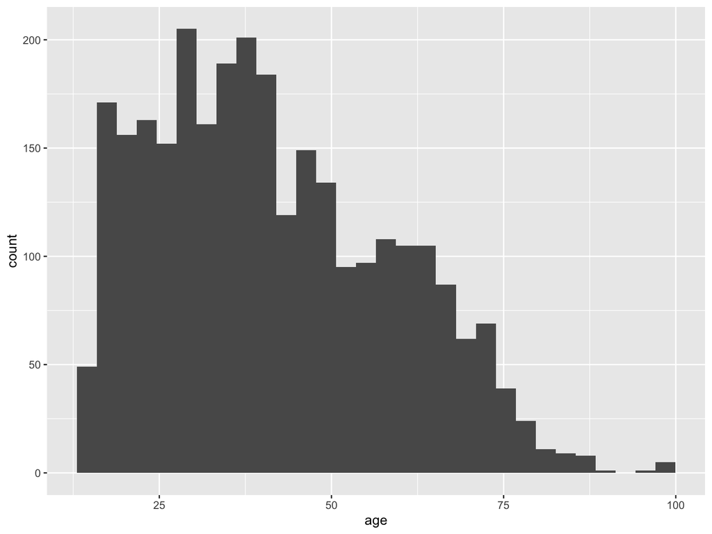

```r
ggplot(crsc96_small) +
  geom_histogram(aes(x = age))
```

## Exemple: histogramme

- Dans le cadre de cette présentation, je mets des options dans le **chunk** (Vous ne les voyez pas dans la présentation regarder le fichier .rmd)
- **out.width** pour préciser la largeur du graphique
- **message = FALSE** : pour ne pas afficher des messages
- **warning = FALSE** : pour ne pas afficher des messages d'avertissement.
- Il faut les utiliser avec précaution. Les messages et les warning nous donnent des informations, par exemple sur les valeurs manquantes.

## Exemple: histogramme

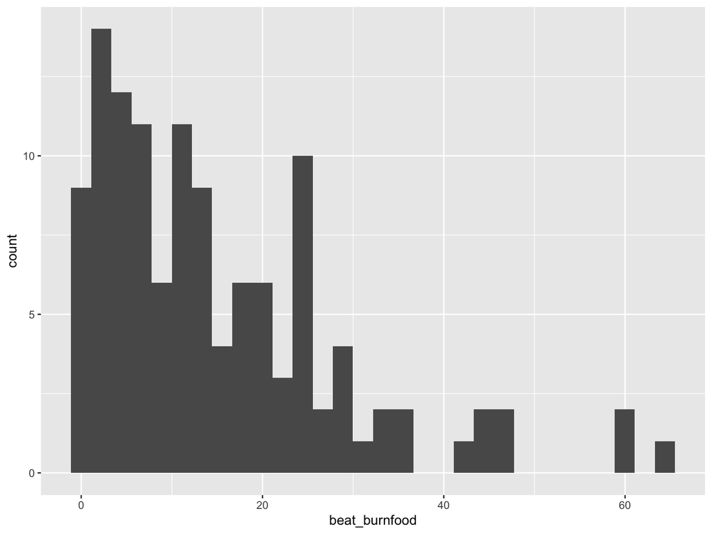

```r
ggplot(dhs_ipv) +
  geom_histogram(aes(x = beat_burnfood))
```

## Exemple: Diagramme en bâtons ou à barres

- Pour résumer la distribution d'une variable **facteur** ou d'une **variable factorielle** (ou d'une variable catégorielle ou qualitative) avec plusieurs catégories, un simple tableau avec des comptes ou des proportions est souvent suffisant.
- Cependant, il est également possible d'utiliser un graphique en barres pour visualiser la distribution.

## Exemple: Diagramme en bâtons

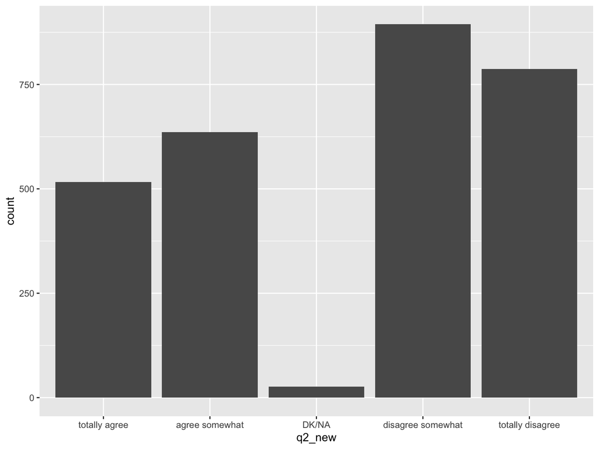

```r
ggplot(crsc96_small) +
  geom_bar(aes(x = q2_new))
```

## Exemple: Diagramme en bâtons

- Dans les graphiques précédents, l'ordonnée (y) est indiqué en effectif. Ceci pose un problème de comparaison entre différents échantillons.
- Dans ce cas, il faut plutôt utiliser les proportions.

## Exemple: Diagramme en bâtons

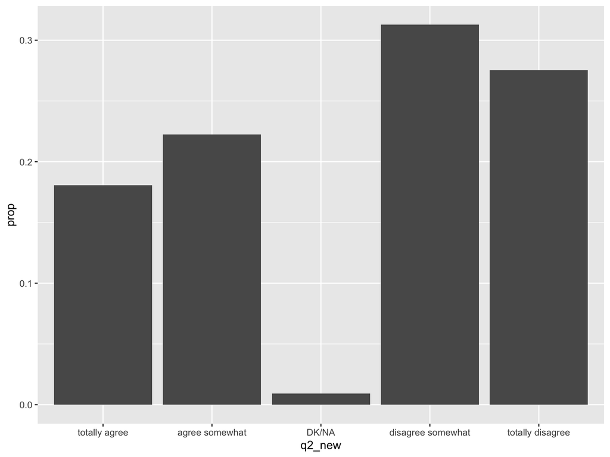

```r
ggplot(crsc96_small) +
  geom_bar(aes(x = q2_new, y = ..prop.., group = 1))
```

## Exemple: Diagramme en bâtons

- Que se passe-t-il si vous ne mettez pas **group = 1**
- On peut représenter ce diagramme par un diagramme circulaire. Comment créer un diagramme circulaire?

## Diagramme circulaire

https://ggplot2.tidyverse.org/reference/coord_polar.html

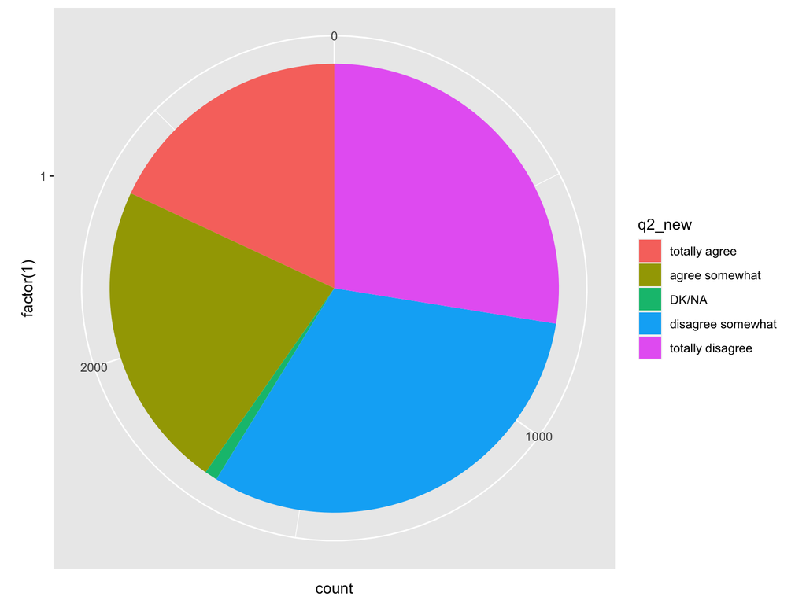

```r
ggplot(crsc96_small) +
  geom_bar(aes(x = factor(1), fill = q2_new), width = 1) +
  coord_polar("y", start = 0)
```

## Exemple: Diagramme de quartile

- La boîte à moustache représente un autre moyen de visualiser les distributions d'une variable numérique.
- Une boîte à moustache visualise **la médiane**, **les quartiles** et **l'écart-interquartile** sous la forme d'un seul objet.

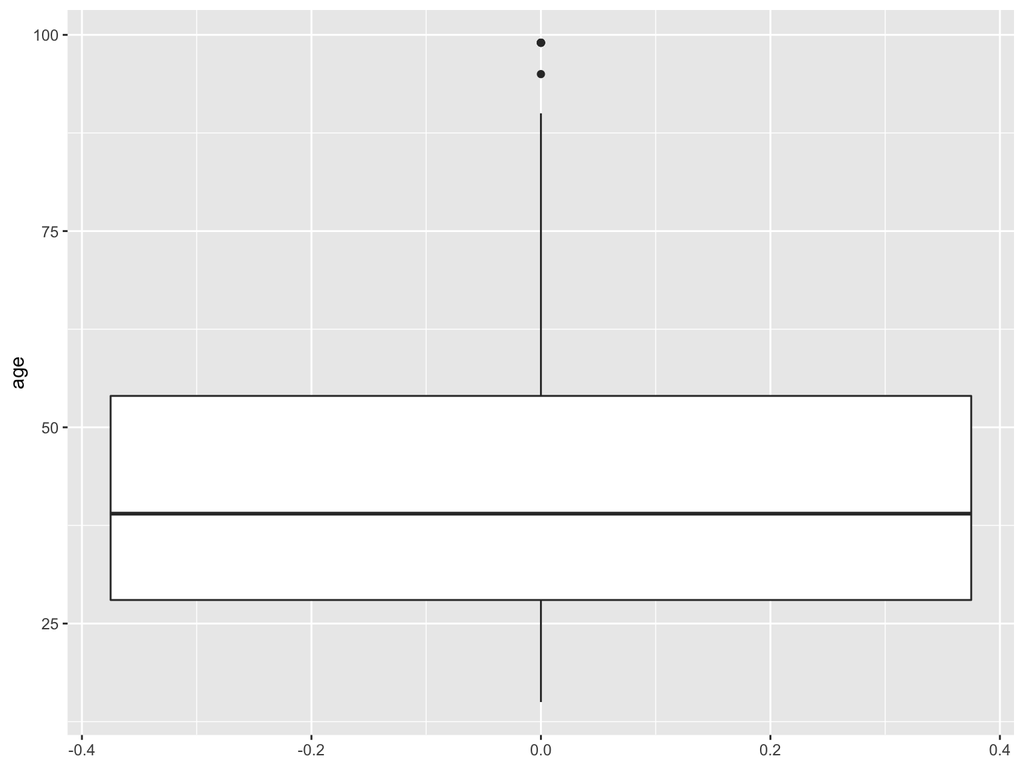

```r
ggplot(crsc96_small) +
  geom_boxplot(aes(y = age))
```

## Exemple: Diagramme de quartile ou boîte à moustaches

- C'est particulièrement utile lorsque vous **comparez la distribution de plusieurs variables** en les plaçant côte à côte.
- `geom_boxplot` permet de représenter des boîtes à moustaches. On lui passe en **y** (axe des ordonnées) la variable dont on veut étudier la répartition (variable quantitative), et en **x** (axe des abscisses) la variable contenant les classes qu’on souhaite comparer (variable qualitative).

# Exemples: Visualiser la distribution bivariée

## Croisement de deux variables qualitatives

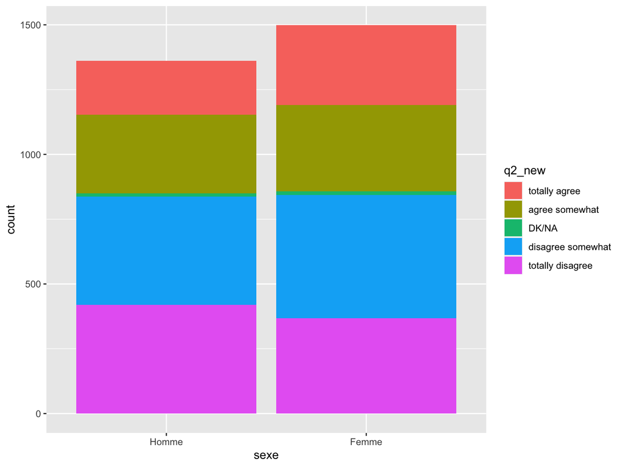

```r
ggplot(crsc96_small) +
  geom_bar(aes(x = sexe, fill = q2_new))
```

- Ce graphique nous donne pour chaque sexe, le nombre de personne qui sont dans chaque catégorie de la variable dépendante.
- Il a cependant un problème, c'est difficile de comparer le nombres bruts. Il faut des pourcentages.

## Croisement de deux variables qualitatives

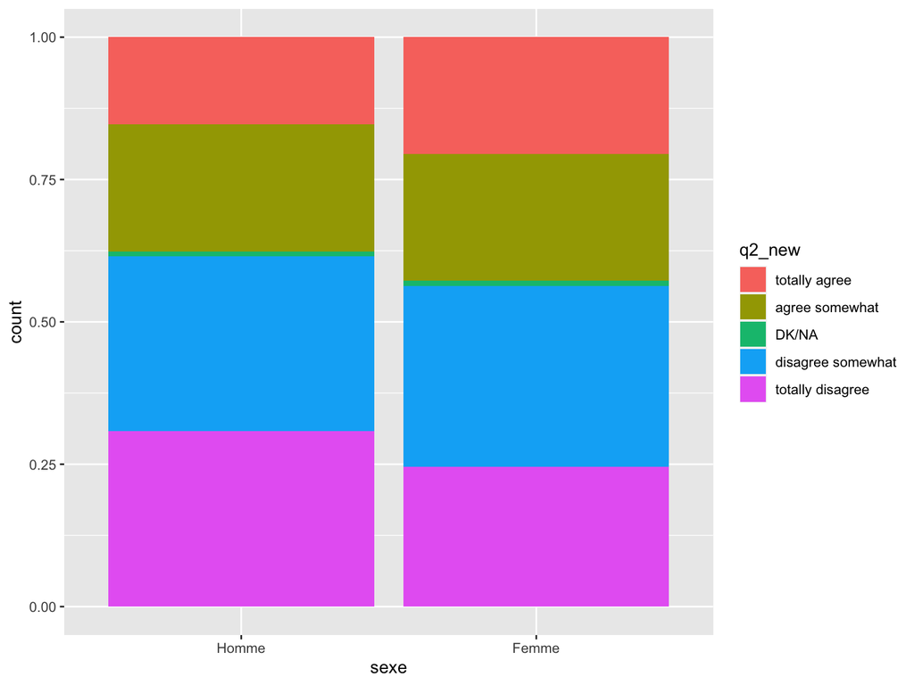

```r
ggplot(crsc96_small) +
  geom_bar(aes(x = sexe, fill = q2_new), position = "fill")
```

- On voit clairement la différence d'opinion entres les hommes et les femmes.

## Croisement de deux variables qualitatives

- On peut changer les couleurs, on verra cela plus loin.
- http://www.sthda.com/french/wiki/couleurs-dans-r

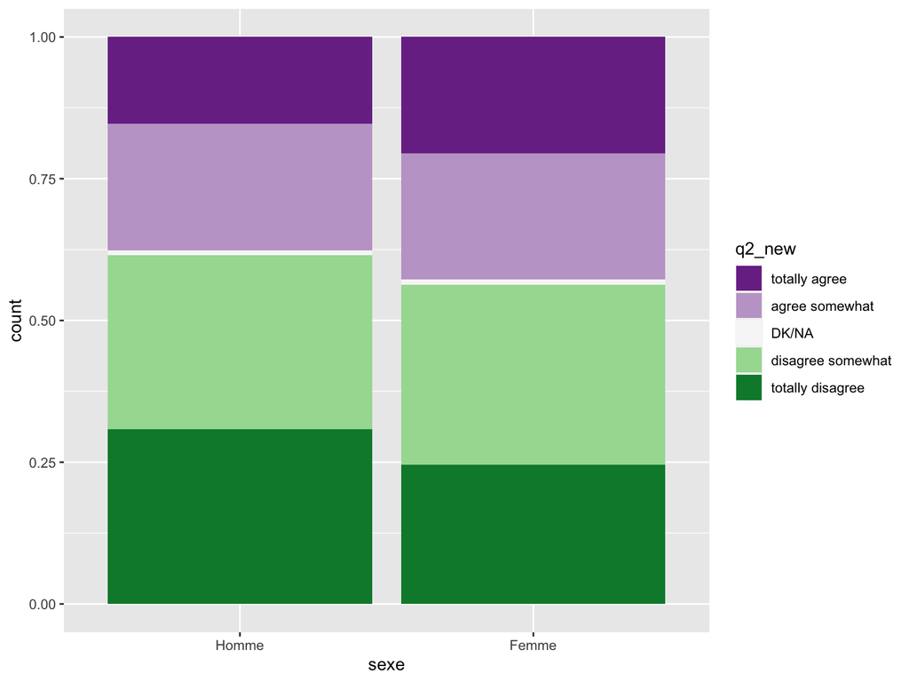

```r
ggplot(crsc96_small) +
  geom_bar(aes(x = sexe, fill = q2_new), position = "fill") +
  scale_fill_brewer(palette="PRGn")
```

```r
# Changer PRGn avec un chiffre
```

## Croisement d'une variable quantitative et d'une variable qualitative

- Croiser une variable quantitative et une variable qualitative, c’est essayé de voir si les valeurs de la variable quantitative se répartissent différemment selon les catégories d’appartenance de la variable qualitative.

## Croisement d'une variable quantitative et d'une variable qualitative

- Avant de présenter ce diagramme, regardons un peu la distribution de la variable beat_burnfood par région.

```r
a <-
ggplot(dhs_ipv) +
  geom_text(aes(x = region, y = beat_burnfood,
                label = country, color = region), size = 2)
```

## Croisement d'une variable quantitative et d'une variable qualitative

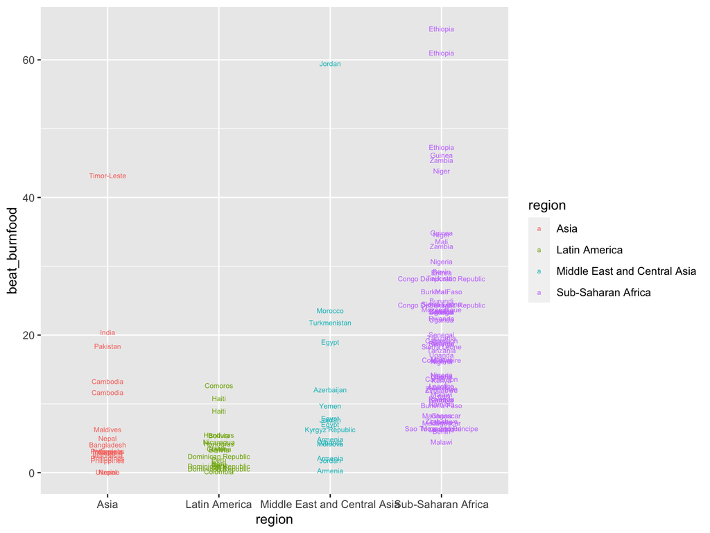

```r
a
```

- Commenter ce graphique.

## Croisement d'une variable quantitative et d'une variable qualitative

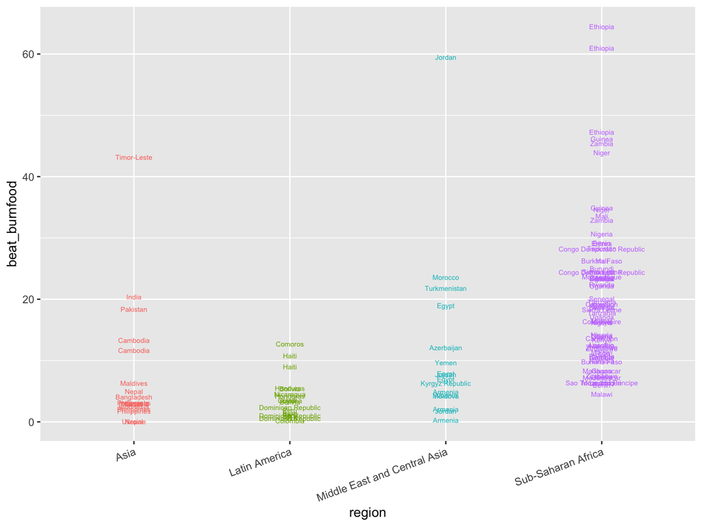

```r
a +
  theme(axis.text.x = element_text(angle = 20, hjust = 1),
        legend.position = "none")
```

## Exemple: Diagramme de quartile

- Le diagramme de quartile permet de synthétiser l'information contenue dans ce nuage de point pour une comparaison plus efficiente.

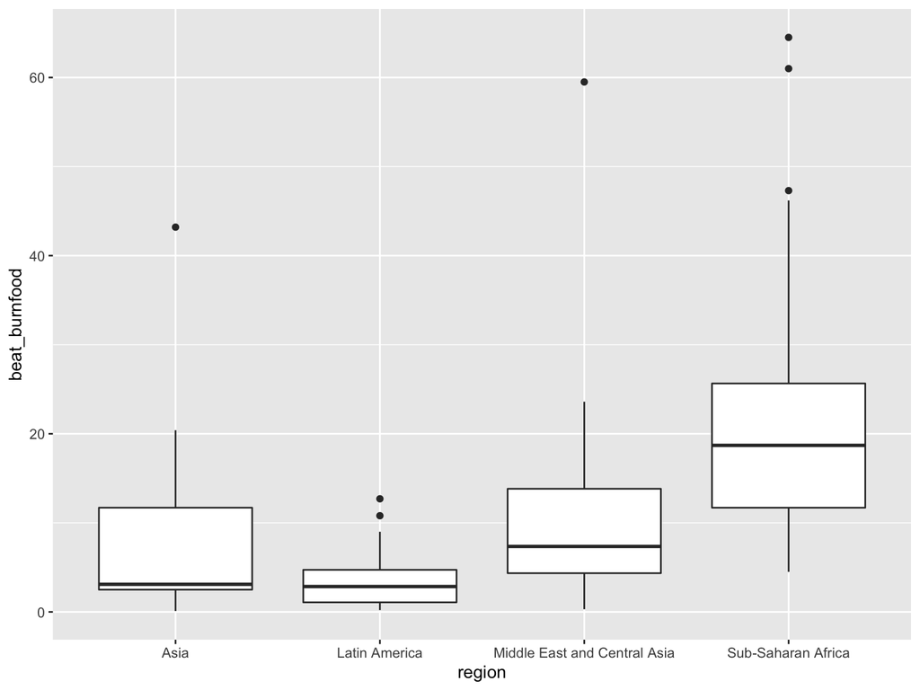

```r
b <- ggplot(dhs_ipv) +
  geom_boxplot(aes(x = region, y = beat_burnfood))
b
```

- Note : x doit être une variable qualitative, et y une variable quantitative.

## Exemple: Diagramme de quartile

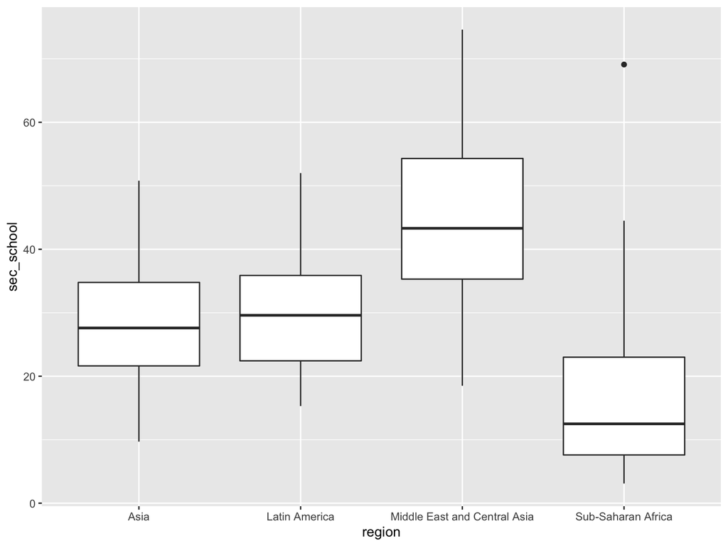

```r
c <- ggplot(dhs_ipv) +
  geom_boxplot(aes(x = region, y = sec_school))
c
```

## Exemple: Diagramme de quartile

- Commencez-vous par tirer une petite conclusion ici?
- Pour bien visualiser le tout, il faut les mettre dans un même graphique. La commande **ggarrange** du package **ggpubr** vous permet de faire cela.

## Exemple: Diagramme de quartile

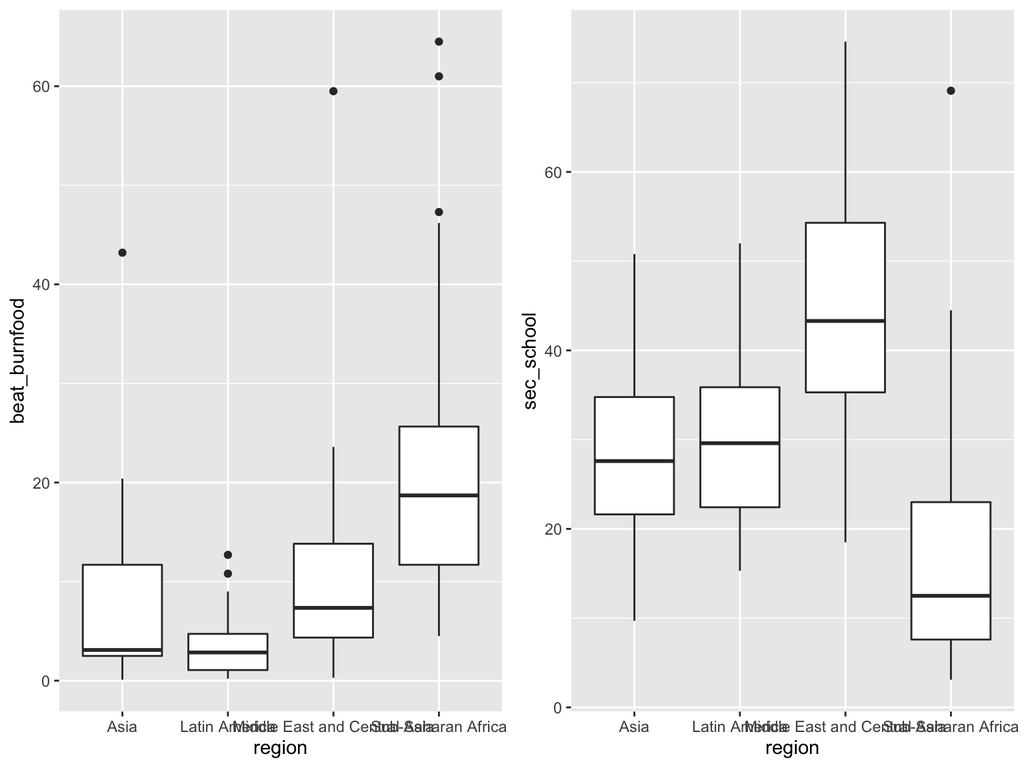

```r
#install.packages("ggpubr")
library(ggpubr)
ggarrange(b, c, ncol = 2)
```

# Association entre deux variables quantitatives

## Corrélation linéaire : Croisement de deux variables quantitatives

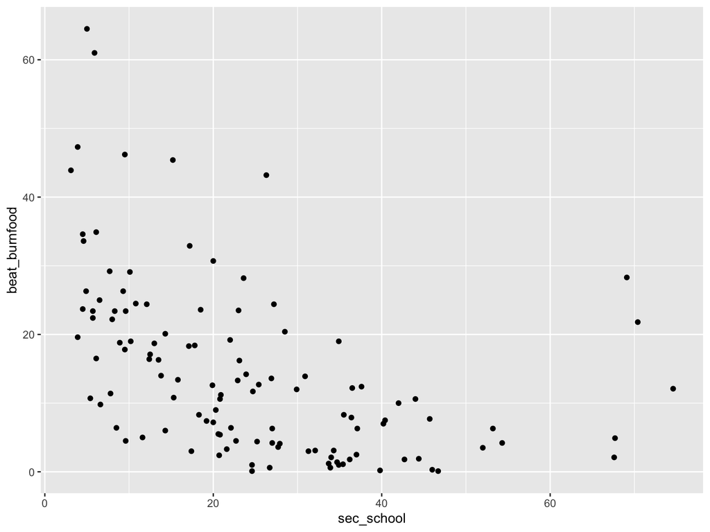

```r
ggplot(dhs_ipv) +
  geom_point(aes(x = sec_school, y = beat_burnfood))
```

## Corrélation linéaire : Croisement de deux variables quantitatives

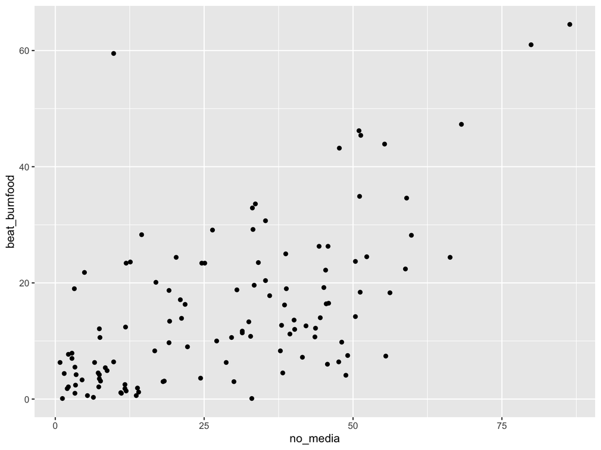

```r
ggplot(dhs_ipv) +
  geom_point(aes(x = no_media, y = beat_burnfood))
```

# Remarques

## Remarques

- Les annotations graphiques sont très utiles pour mettre en évidence les messages clés.
- Dans un bulletin ou un rapport statistique, tous les graphiques doivent être étiquetés comme des figures et numérotés, en fonction de leur ordre d'apparition.
- Ecrire clairement les titres : préciser la région et la période.
- Soyez concis, en nommant les principaux axes du graphique.
- Le texte du graphique doit être horizontal.
- Si les étiquettes ne tiennent pas dans l’espace requis, transposez le graphique ou convertissez les unités.
- Elles doivent être concises et pertinentes.
- Placez les sur le graphique aussi près que possible des points de données qui vous intéressent.
- Indiquer la source

## Remarques

https://slideplayer.fr/slide/10114066/

## Pour aller plus loin

- Plus dans aes : **mappage** : c'est une mise en relation entre un **attribut graphique du geom** et une variable du tableau de données.
- Changer les couleurs (*color*), la taille (*size*), la position (*position*), la transparence (*alpha*), le remplissage (*fill*)
- **Facets** : le **faceting** permet d’effectuer plusieurs fois le même graphique selon les valeurs d’une ou plusieurs variables qualitatives (notre *group_by*): facet_wrap, facet_grid
- Les **scales** : ils permettent de modifier la manière dont un attribut graphique va être relié aux valeurs d’une variable, et dont la légende correspondante va être affichée.
- Les **thèmes** : ils permettent de contrôler l’affichage de tous les éléments du graphique qui ne sont pas reliés aux données : **titres**, **grilles**, **fonds**, etc. https://ggplot2.tidyverse.org/reference/theme.html

## Pour aller plus loin : exemple 1

```r
d <- ggplot(dhs_ipv) +
  geom_point(aes(x = no_media, y = beat_burnfood,
                 color = region)) +
  geom_smooth(aes(x = no_media, y = beat_burnfood,
                  color = region),
              method = lm, se = FALSE,  formula = y ~ x) +
  labs(title = "Association entre accès aux médias et attitudes face à la violence",
       x = "Non accès aux médias (%)",
       y = "Battre si brûle la nourriture (%)") +
  theme(legend.position = "bottom", legend.direction = "horizontal")
```

## Pour aller plus loin : exemple 1

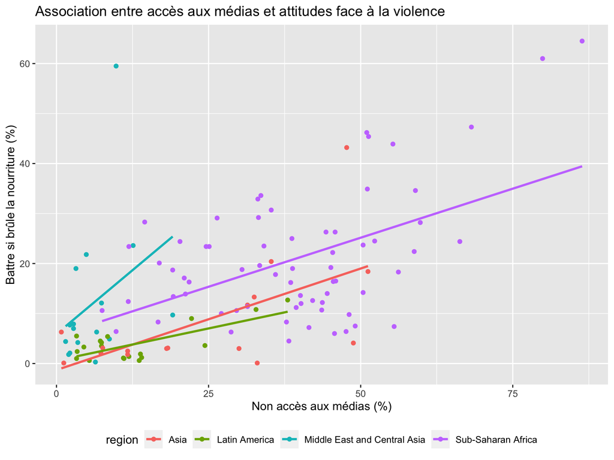

```r
d
```

## Pour aller plus loin : exemple 2

```r
e <- ggplot(dhs_ipv) +
  geom_point(aes(x = no_media, y = beat_burnfood, color = beat_burnfood)) +
  scale_color_gradient("beat_burnfood", low = "blue", high = "red") +
# scale_size(range = c(0,4), breaks = c(15, 25, 35, 45)) +
  facet_wrap(~region) +
  labs(title = "Association entre accès aux médias et attitudes face à la violence",
       x = "Non accès aux médias (%)",
       y = "Battre si brûle la nourriture (%)",
       "region" = "Région")  +
  theme_bw()
```

## Pour aller plus loin : exemple 2

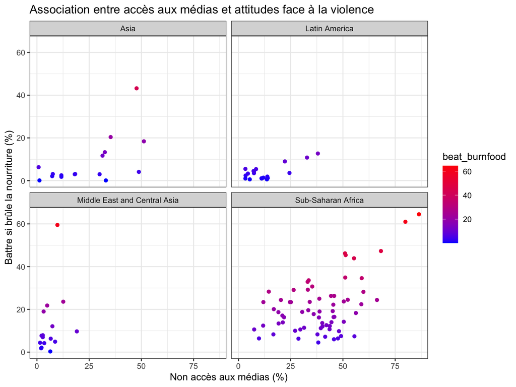

```r
e
```

# Ressources

## Ressources

- https://www.google.com/search?q=ggplot+theme%2C+dont+show+legend&oq=ggplot+theme%2C+dont+show+legend&aqs=chrome..69i57j0.7717j0j4&sourceid=chrome&ie=UTF-8
- https://juba.github.io/tidyverse/08-ggplot2.html#
- Fortement recommandé
- https://www.rstudio.com/resources/cheatsheets/
- http://r4ds.had.co.nz/data-visualisation.html#aesthetic-mappings
- http://r-statistics.co/Top50-Ggplot2-Visualizations-MasterList-R-Code.html
- http://www.cookbook-r.com/Graphs/
- http://www.ggplot2-exts.org/gallery/
- Si vous y trouver de la passion...